# Even and Odd Functions

Mr. Worley

2025 Sep 9

# Entrance ticket!

Complete the entrance ticket: [ET_09_09](https://bart.instructure.com/courses/2110/quizzes/3171)

Each term of a polynomial is either ODD powered or EVEN powered.

To find $f(-x)$ from polynomial $f(x)$, switch sign on ODD powered terms.

To find $-f(-x)$ from polynomial $f(x)$, switch sign on EVEN powered terms.

To find $-f(x)$ from polynomial $f(x)$, switch sign on ALL terms.

The linear term (like $-5x$ or $+6x$) is an ODD powered term, because $x^1\equiv x$. (And 1 is ODD.)

The constant term (like $-5$ or $+6$) is an EVEN powered term, because $x^0 \equiv 1$. (And 0 is EVEN.)

# Graphical examples

- Let two functions be defined with polynomials:
  $$f(x)=x^5+x^4+x^3+x^2+x+1$$
  $$g(x)=-x^5+x^4-x^3+x^2-x+1$$
  What type of reflection relates these two functions?
- Since the ODD powered terms have their signs changed, it seems $g(x)~=~f(-x)$, so the two curves $y=f(x)$ and $y=g(x)$ are horizontal reflections over the $y$ axis.

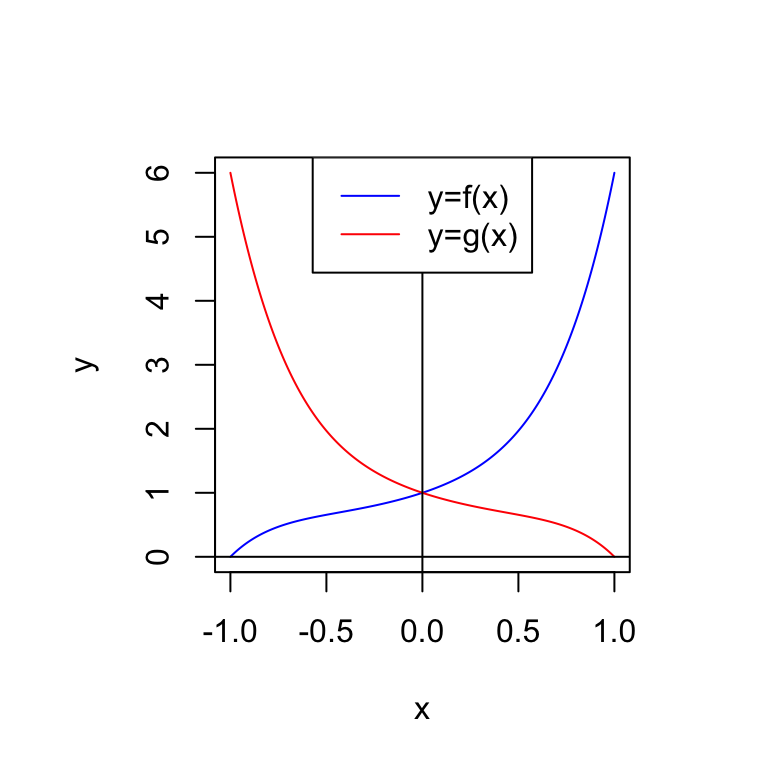

- Let two functions be defined with polynomials:
  $$f(x)=x^5+x^4+x^3+x^2+x+1$$
  $$h(x)=-x^5-x^4-x^3-x^2-x-1$$
  What type of reflection relates these two functions?
- Since ALL terms have their signs changed, it seems $h(x)~=~-f(x)$, so the two curves $y=f(x)$ and $y=h(x)$ are vertical reflections over the $x$ axis.

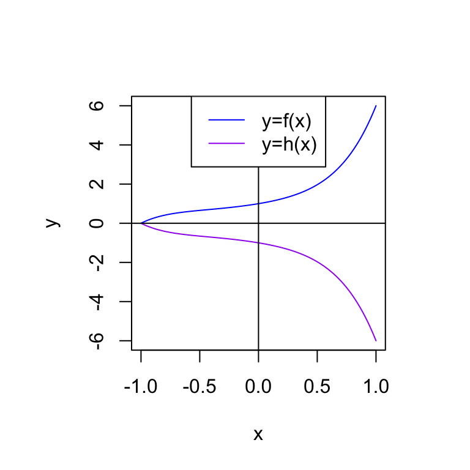

- Let two functions be defined with polynomials:
  $$f(x)=x^5+x^4+x^3+x^2+x+1$$
  $$j(x)=x^5-x^4+x^3-x^2+x-1$$
  What type of reflection relates these two functions?
- Since the EVEN powered terms have their signs changed, it seems $j(x)~=~-f(-x)$, so the two curves $y=f(x)$ and $y=j(x)$ are 180° rotations around the origin.

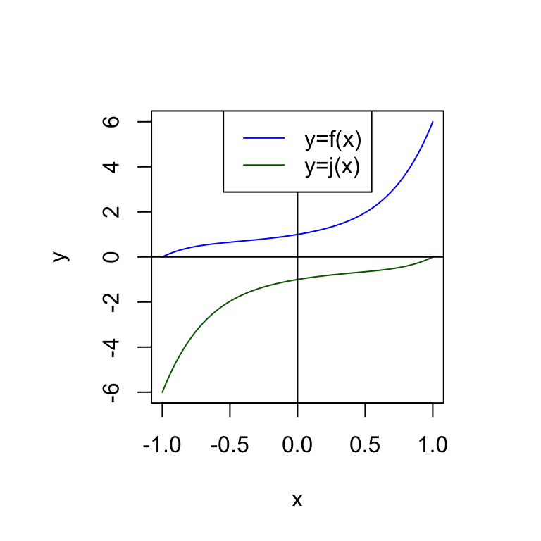

# Define an EVEN function

- A function is **even** if and only if $f(x)=f(-x)$ for all values of $x$ in the domain of the function.
- An example of an even polynomial is $f(x)=5x^8+4x^6-3x^4+9x^2-7$.
  - Notice it only has EVEN powered terms.
- In an even function **opposite inputs give equal outputs**.
- Here is another **even** function:

  | $x$ | $f(x)$ |
  | --- | --- |
  | -4 | 5 |
  | -3 | 3 |
  | -2 | 7 |
  | -1 | 4 |
  | 0 | -3 |
  | 1 | 4 |
  | 2 | 7 |
  | 3 | 3 |
  | 4 | 5 |

- Even functions have reflective symmetry over the $y$ axis.

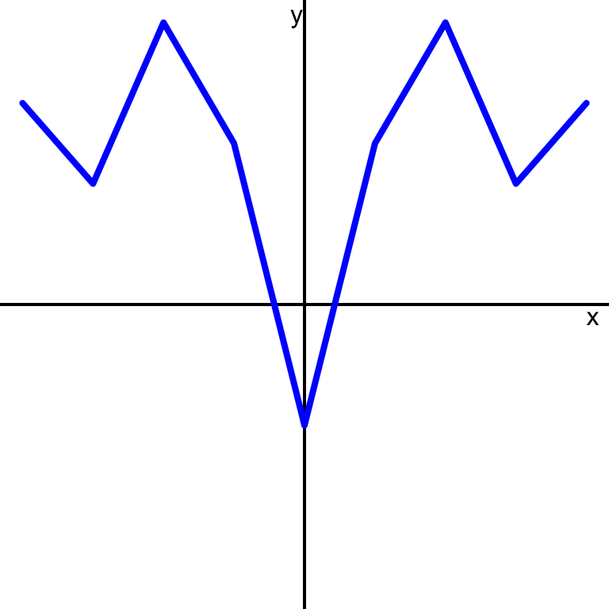

# Define an ODD function

- A function is **odd** if and only if $f(x)=-f(-x)$ for all values of $x$ in the domain of the function.
- An example of an odd polynomial is $f(x)=5x^9+4x^7-3x^5+9x^3-7x$.
  - Notice it only has ODD powered terms.
- In an odd function **opposite inputs give opposite outputs**.
- Here is another **odd** function:

  | $x$ | $f(x)$ |
  | --- | --- |
  | -4 | -5 |
  | -3 | -3 |
  | -2 | 7 |
  | -1 | 4 |
  | 0 | 0 |
  | 1 | -4 |
  | 2 | -7 |
  | 3 | 3 |
  | 4 | 5 |

- Odd functions have 180° rotational symmetry around the origin.

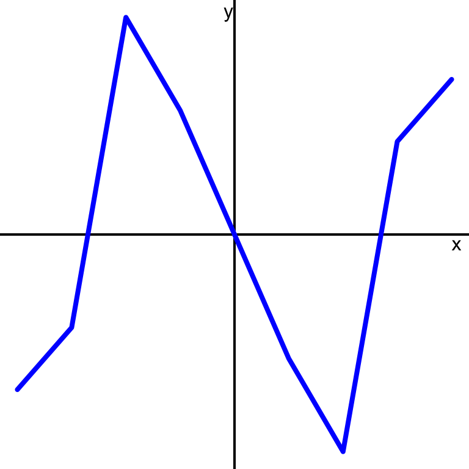

# Is it possible…

Can a function be neither even nor odd?

- Indeed, most functions are neither even nor odd. For example $y=2x+3$ is neither even nor odd because it is the sum of an odd term (the linear term, $2x$) and an even term (the constant, $3$).
- You could prove this by recognizing $2(-x)+3$ is not equivalent to $2x+3$, and also $-(2(-x)+3)$ is not equivalent to $2x+3$.

# Classwork

- [OCW_0909_even_odd_funcs](https://bart.instructure.com/courses/2110/quizzes/3173)
- [PCW_draw_even_or_odd](https://chadworley.github.io/algtwo2026/daily_materials/day008/PCW_draw_even_or_odd/PCW/PCW_draw_even_or_odd.html)